# aturin1

# Prolegómeno

Recordemos que Abundio estaba cogiendo espárragos en [las afueras](https://jmb-uma.github.io/rbund), una región del espacio-tiempo peculiar. Gracias a un sueño en el que aparecieron sus amigos de cuando chicho, pudo descartar las estrategias basadas en puro azar inventado un [algoritmo basado en estados](https://jmb-uma.github.io/trbund).

Ahora le asaltaba la duda de si ese algoritmo podría ser equivalente a otro direccional, basado en que cada estado era una orientación del autómata.

# El autómata direccional

Como había 4 direcciones fundamentales `Norte, Este, Sur, Oeste` el autómata tendría también cuatro estados. El siguiente movimiento quedaría determinado por la dirección en la que estuviera mirando y el siguiente estado por lo que encontrase en la nueva casilla y las instrucciones de su cromosoma.

[figure not shown]

**Figura 1. Autómata direccional.** Las filas representan la dirección en la que avanza y las columnas el valor de la casilla que se encuentre. En cada intersección de ambas hay dos caracteres: lo que escribirá en la casilla `0, 1` y la dirección que tomará a continuación `(D)erecha, (I)zquierda, (A)delante, at(R)ás`. El diagrama expresa lo mismo, pero con flechas. No aparece lo que haría si se encontrara un espárrago… ¡ya se lo inventará él!

Las unidadades del cromosoma solo tienen 2 caracteres porque el estado al que cambia está determinado por el segundo elemento. Esto, en principio, parece una desventaja con respecto al modelo anterior porque tiene menos combinaciones.

Veamos…

```
[1] "1 011103110210031011110313 74"
```

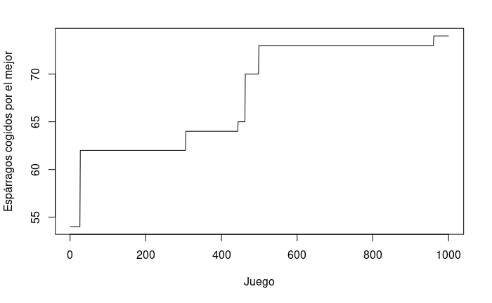

```r
# Autómata direccional
{

#---- Espacio y esparragueras
xmax <- 100  # ancho de la pradera (desde x = 1 hasta x = 100)
ymax <- 100  # largo "        "    (desde y = 1 hasta y = 100)
esp <- 9
xe <- runif(esp)
ye <- runif(esp)
re <- round(runif(esp, min = 1, max = 6))

#---- Veces
veces <- 1000
mejor <- numeric(veces)

#---- Tiempo
pasos <- 800

#---- Movimiento
Dx <- c(0, 1, 0, -1)
Dy <- c(1, 0, -1, 0)
rota <- c(0, 270, 180, 90)

#---- Estados
estados <- "NESO"

#---- Autómatas
automatas <- 12

#---- Cromosomas al azar
cromNa <- character()
for (i in 1:automatas){
  cromNa[i] <- ""
  for (j in 1:nchar(estados)) {
    for (k in 1:3){
      cromNa[i] <- paste(cromNa[i], sample(c(0,1), 1), sep = "") # lo que escribe
      cromNa[i] <- paste(cromNa[i], sample(c(0,1,2,3), 1), sep = "") # donde gira
    }
  }
}

#---- Espárragos
Aea <- numeric(automatas)


for (vez in 1:veces){

    #---- Posición de las esparragueras
    XYespar <- matrix(0, xmax, ymax)
    # pixelar la Figura 2
    for (k in 1:esp){
      x <- ceiling(xmax*xe[k])
      y <- ceiling(ymax*ye[k])
      # ¿Cómo pixelar un círculo con teselas de lado = 1?
      for (yi in 0:re[k]){
        y_arr <- y + yi
        if(y_arr > ymax) {y_arr <- y_arr - ymax} # por si se sale
        y_abj <- y - yi
        if(y_abj < 1) {y_abj <- ymax + y_abj}
        borde <- sqrt(re[k]^2 - yi^2)
        for (xi in 0:borde){
          x_der <- x + xi
          if(x_der > xmax) {x_der <- x_der - xmax}
          x_izq <- x - xi
          if(x_izq < 1) {x_izq <- xmax + x_izq}
          # points(x_der, y_arr, pch = 15, col = c_espar, cex = 0.6)
          XYespar[x_der, y_arr] <- 2
          # points(x_izq, y_arr, pch = 15, col = c_espar, cex = 0.6)
          XYespar[x_izq, y_arr] <- 2
          # points(x_der, y_abj, pch = 15, col = c_espar, cex = 0.6)
          XYespar[x_der, y_abj] <- 2
          # points(x_izq, y_abj, pch = 15, col = c_espar, cex = 0.6)
          XYespar[x_izq, y_abj] <- 2
        }
      }
    }

    XYespar_ini <- XYespar

    #---- JUGAR DE UNO EN UNO

    for (i in 1:automatas){

        #---- Pradera con esparragueras
        XYespar <- XYespar_ini
        # XYespar <- t(as.matrix(read.table("XYesp.txt")))

        #---- Posición y estado iniciales
        Ax <- ceiling(0.5*xmax)
        Ay <- ceiling(0.5*ymax)
        As <- 0  # mirando al norte
        Ae <- 0  # sin espárragos

        #---- Paseo
        for (t in 2:pasos){

          # Mirar qué hay en la casilla
          huella  <- XYespar[Ax, Ay]

          # Coger espárrago (si lo hubiera)
          if (huella == 2) {Ae <- Ae + 1}

          # Aplicar la regla

          posi <- 6*As + 2*huella + 1  # para la nueva huella
          n_huella <- as.numeric(substring(cromNa[i], posi, posi))
          XYespar[Ax, Ay] <- n_huella

          posi <- 6*As + 2*huella + 2  # para el giro
          Ad <- as.numeric(substring(cromNa[i], posi, posi))

          As <- (As + Ad) %% 4

          # Moverse

          Ax <- Ax + Dx[As+1]
          Ay <- Ay + Dy[As+1]
          if(Ax > xmax) {Ax <- 1} # por si se sale
          if(Ax < 1) {Ax <- xmax}
          if(Ay > ymax) {Ay <- 1}
          if(Ay < 1) {Ay <- ymax}

        }

        #---- Asignar puntos
        Aea[i] <- Ae
    }

    #---- Ver quién gana y pierde
    e_ganador <- max(Aea)
    ganador <- min(which(Aea == e_ganador)) # para que solo salga uno
    e_pringao <- min(Aea)
    pringao <- min(which(Aea == e_pringao)) # para que solo salga uno
    mejor[vez] <- e_ganador

    # Pa grabá al ganador
    if (vez == veces) {
     write(XYespar_ini, "XYesp_dir.txt", ncolumns = xmax)
     print(paste(ganador, cromNa[ganador], e_ganador))
    }

    #---- Tranfulla 1 (copiar del ganador)
    amigo <- ganador  # para copiar el resto del cartón
    while (amigo == ganador){
      amigo <- floor(automatas*runif(1)) + 1
    }
    l_cromo <- nchar(cromNa[1])
    pc <- floor(l_cromo*runif(1)) + 1
    fc <- floor(l_cromo*runif(1)) + 1

    if (pc < fc) {
      cromNa[pringao] <- cromNa[amigo]
      substring(cromNa[pringao], pc, fc-1) <- substring(cromNa[ganador], pc, fc-1)
    }

    if (fc < pc) {
      cromNa[pringao] <- cromNa[ganador]
      substring(cromNa[pringao], fc, pc-1) <- substring(cromNa[amigo], fc, pc-1)
    }


    #---- Tranfulla 2 (cambiar algún número al tuntún)
    amigo <- floor(automatas*runif(1)) + 1
    pc <- floor(l_cromo*runif(1)) + 1
    pcc <- substring(cromNa[amigo], pc, pc)
    ifelse(pc%%2 == 0,
           # cambia el tipo de giro
           substring(cromNa[amigo], pc, pc) <- as.character((as.numeric(pcc)+1)%%4),
           # cambia la nueva huella
           substring(cromNa[amigo], pc, pc) <- as.character((as.numeric(pcc)+1)%%2))

}
plot(mejor, type = "l", ylab = "Espárragos cogidos por el mejor", xlab = "Juego")
}
```

**Figura 1. Evolución del autómata direccional.** No lo hace mal, a pesar de ser menos versátil que los multiestados anteriores.

# Comparación entre multiestado y direccional

Pa verlo mejor, aquí tenemos unos vídeos:

`MULTIESTADO (4)`

[video not shown]

`DIRECCIONAL`

[video not shown]

**Figura 2. Comparación entre un autómata de 4 estados y otro direccional.** Ambos autómatas han evolucionado durante 1000 juegos. Cuando juegan en su casa (izquierda: casa del direccional, derecha: casa del multiestado) cada uno demuestra su valía y vence al otro que, por cierto, no se come una rosca. Sin embargo, en terreno neutral (centro) ambos sacan algo pero el multiestado demuestra su mayor versatilidad.

# ¡Contra la gorda!

¿Qué pasaría si todos los espárragos estuvieran concentrados en una sola y magnánima esparraguera?, por ejemplo:

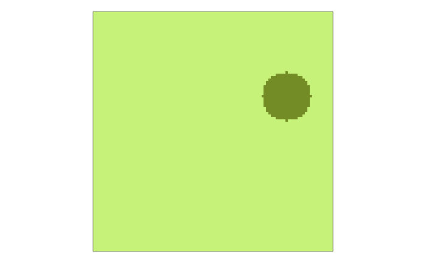

```r
{
#---- Colores
c_campo <- rgb(0.78, 0.95, 0.48)
c_amg <- rgb(0, 0.31, 0.74)
c_espar <- rgb(0.45, 0.55, 0.15)

#---- Espacio y esparragueras
xmax <- 100  # ancho de la pradera (desde x = 1 hasta x = 100)
ymax <- 100  # largo "        "    (desde y = 1 hasta y = 100)
esp <- 1
xe <- 0.81
ye <- 0.65
re <- 10

#---- Posición de las esparragueras
XYespar <- matrix(0, xmax, ymax)
# pixelar la esparraguera
for (k in 1:esp){
  x <- ceiling(xmax*xe[k])
  y <- ceiling(ymax*ye[k])
  # ¿Cómo pixelar un círculo con teselas de lado = 1?
  for (yi in 0:re[k]){
    y_arr <- y + yi
    if(y_arr > ymax) {y_arr <- y_arr - ymax} # por si se sale
    y_abj <- y - yi
    if(y_abj < 1) {y_abj <- ymax + y_abj}
    borde <- sqrt(re[k]^2 - yi^2)
    for (xi in 0:borde){
      x_der <- x + xi
      if(x_der > xmax) {x_der <- x_der - xmax}
      x_izq <- x - xi
      if(x_izq < 1) {x_izq <- xmax + x_izq}
      # points(x_der, y_arr, pch = 15, col = c_espar, cex = 0.6)
      XYespar[x_der, y_arr] <- 2
      # points(x_izq, y_arr, pch = 15, col = c_espar, cex = 0.6)
      XYespar[x_izq, y_arr] <- 2
      # points(x_der, y_abj, pch = 15, col = c_espar, cex = 0.6)
      XYespar[x_der, y_abj] <- 2
      # points(x_izq, y_abj, pch = 15, col = c_espar, cex = 0.6)
      XYespar[x_izq, y_abj] <- 2
    }
  }
}
XYespar_ini <- XYespar

#---- Pradera con esparragueras
par(pty = "s", mar = c(1, 1, 1, 1), xaxt = "n", yaxt = "n",
    xaxs = "i", yaxs="i", ann = FALSE)

#---- Dibujar las esparragueras
image(x = 1:xmax, y = 1:ymax, XYespar_ini, xlim = c(1,xmax),
      ylim = c(1,ymax), col = c(c_campo, c_amg, c_espar))

#---- Guardar la matriz de esparragueras
write(XYespar_ini, "XYesp_gorda.txt", ncolumns = xmax)
}
```

**Figura 3. La gorda.** Sobran las palabras.

## Evolución del multiestado 4

¡A ver si la encuentra!

```
[1] "1 112110143043140130142120041020023130 299"
```

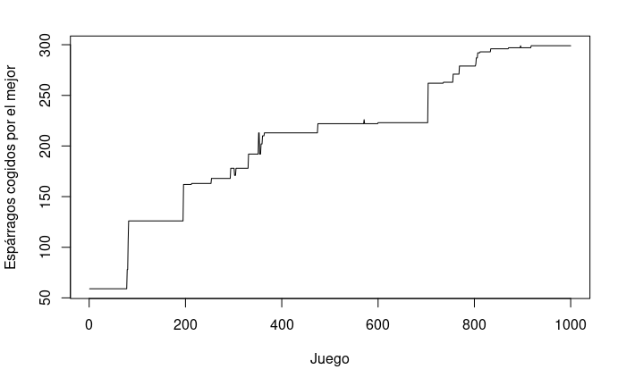

```r
# multiestado 4 contra la gorda
{

#---- Espacio y esparragueras iniciales
xmax <- 100  # ancho de la pradera (desde x = 1 hasta x = 100)
ymax <- 100  # largo "        "    (desde y = 1 hasta y = 100)
XYespar_ini <- t(as.matrix(read.table("XYesp_gorda.txt")))

#---- Veces
veces <- 1000
mejor <- numeric(veces)

#---- Tiempo
pasos <- 1200

#---- Movimiento
Dx <- c(0, 1, 0, -1)
Dy <- c(1, 0, -1, 0)
rota <- c(0, 270, 180, 90)

#---- Estados
estados <- "ABUN"

#---- Autómatas
automatas <- 12

#---- Cromosomas al azar
cromNa <- character()
for (i in 1:automatas){
  cromNa[i] <- ""
  for (j in 1:nchar(estados)) {
    for (k in 1:3){
      cromNa[i] <- paste(cromNa[i], sample(c(0,1), 1), sep = "") # lo que escribe
      cromNa[i] <- paste(cromNa[i], sample(c(1,2,3,4), 1), sep = "") # donde se mueve
      cromNa[i] <- paste(cromNa[i], sample(c(0,1,2,3), 1), sep = "") # nuevo estado
    }
  }
}

#---- Espárragos
Aea <- numeric(automatas)


for (vez in 1:veces){

    #---- JUGAR DE UNO EN UNO

    for (i in 1:automatas){

        #---- Pradera con esparragueras
        XYespar <- XYespar_ini

        #---- Posición y estado iniciales
        Ax <- ceiling(0.5*xmax)
        Ay <- ceiling(0.5*xmax)
        As <- 0  # estado A
        Ae <- 0  # sin espárragos

        #---- Paseo
        for (t in 2:pasos){

          # Mirar qué hay en la casilla
          huella  <- XYespar[Ax, Ay]

          # Coger espárrago (si lo hubiera)
          if (huella == 2) {Ae <- Ae + 1}

          # Aplicar la regla

          posi <- 9*As + 3*huella + 1  # para la nueva huella
          n_huella <- as.numeric(substring(cromNa[i], posi, posi))
          XYespar[Ax, Ay] <- n_huella

          posi <- 9*As + 3*huella + 2  # para el movimiento
          Ad <- as.numeric(substring(cromNa[i], posi, posi))

          posi <- 9*As + 3*huella + 3  # para el estado
          n_As <- as.numeric(substring(cromNa[i], posi, posi))
          As <- n_As

          # Moverse

          Ax <- Ax + Dx[Ad]
          Ay <- Ay + Dy[Ad]
          if(Ax > xmax) {Ax <- 1} # por si se sale
          if(Ax < 1) {Ax <- xmax}
          if(Ay > ymax) {Ay <- 1}
          if(Ay < 1) {Ay <- ymax}

        }

        #---- Asignar puntos
        Aea[i] <- Ae
    }

    #---- Ver quién gana y pierde
    e_ganador <- max(Aea)
    ganador <- min(which(Aea == e_ganador)) # para que solo salga uno
    e_pringao <- min(Aea)
    pringao <- min(which(Aea == e_pringao)) # para que solo salga uno
    mejor[vez] <- e_ganador

    # Pa grabá al ganador
    if (vez == veces) {
     print(paste(ganador, cromNa[ganador], e_ganador))
    }


    #---- Tranfulla 1 (copiar del ganador)
    amigo <- ganador  # para copiar el resto del cartón
    while (amigo == ganador){
      amigo <- floor(automatas*runif(1)) + 1
    }
    l_cromo <- nchar(cromNa[1])
    pc <- floor(l_cromo*runif(1)) + 1
    fc <- floor(l_cromo*runif(1)) + 1

    if (pc < fc) {
      cromNa[pringao] <- cromNa[amigo]
      substring(cromNa[pringao], pc, fc-1) <- substring(cromNa[ganador], pc, fc-1)
    }

    if (fc < pc) {
      cromNa[pringao] <- cromNa[ganador]
      substring(cromNa[pringao], fc, pc-1) <- substring(cromNa[amigo], fc, pc-1)
    }


    #---- Tranfulla 2 (cambiar algún número al tuntún)
    amigo <- floor(automatas*runif(1)) + 1
    pc <- floor(l_cromo*runif(1)) + 1
    pcc <- substring(cromNa[amigo], pc, pc)
    ifelse(pc%%3 == 0, # cambia el estado final
           substring(cromNa[amigo], pc, pc) <- as.character((as.numeric(pcc)+1)%%4),
           ifelse(pc%%3 == 1, # cambia la nueva huella
                  substring(cromNa[amigo], pc, pc) <- as.character((as.numeric(pcc)+1)%%2),
                  substring(cromNa[amigo], pc, pc) <- as.character((as.numeric(pcc)+1)%%4 + 1)
           ))
}
plot(mejor, type = "l", ylab = "Espárragos cogidos por el mejor", xlab = "Juego")
}
```

`MULTIESTADO (4)`

[video not shown]

## Evolución del direccional

¡A ver si la encuentra!

```
[1] "2 010200130112101203030111 209"
```

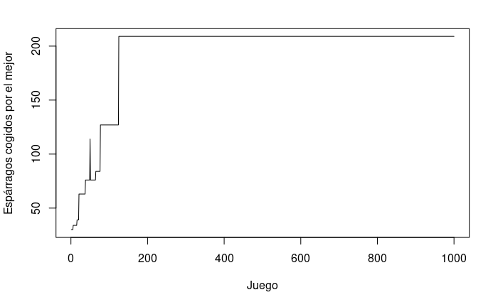

```r
# Autómata direccional contra la gorda
{

#---- Espacio y esparragueras iniciales
xmax <- 100  # ancho de la pradera (desde x = 1 hasta x = 100)
ymax <- 100  # largo "        "    (desde y = 1 hasta y = 100)
XYespar_ini <- t(as.matrix(read.table("XYesp_gorda.txt")))

#---- Veces
veces <- 1000
mejor <- numeric(veces)

#---- Tiempo
pasos <- 1200

#---- Movimiento
Dx <- c(0, 1, 0, -1)
Dy <- c(1, 0, -1, 0)
rota <- c(0, 270, 180, 90)

#---- Estados
estados <- "AAAA"

#---- Autómatas
automatas <- 12

#---- Cromosomas al azar
cromNa <- character()
for (i in 1:automatas){
  cromNa[i] <- ""
  for (j in 1:nchar(estados)) {
    for (k in 1:3){
      cromNa[i] <- paste(cromNa[i], sample(c(0,1), 1), sep = "") # lo que escribe
      cromNa[i] <- paste(cromNa[i], sample(c(0,1,2,3), 1), sep = "") # donde gira
    }
  }
}

#---- Espárragos
Aea <- numeric(automatas)


for (vez in 1:veces){

    #---- JUGAR DE UNO EN UNO

    for (i in 1:automatas){

        #---- Pradera con esparragueras
        XYespar <- XYespar_ini

        #---- Posición y estado iniciales
        Ax <- ceiling(0.5*xmax)
        Ay <- ceiling(0.5*ymax)
        As <- 0  # mirando al norte
        Ae <- 0  # sin espárragos

        #---- Paseo
        for (t in 2:pasos){

          # Mirar qué hay en la casilla
          huella  <- XYespar[Ax, Ay]

          # Coger espárrago (si lo hubiera)
          if (huella == 2) {Ae <- Ae + 1}

          # Aplicar la regla

          posi <- 6*As + 2*huella + 1  # para la nueva huella
          n_huella <- as.numeric(substring(cromNa[i], posi, posi))
          XYespar[Ax, Ay] <- n_huella

          posi <- 6*As + 2*huella + 2  # para el giro
          Ad <- as.numeric(substring(cromNa[i], posi, posi))

          As <- (As + Ad) %% 4

          # Moverse

          Ax <- Ax + Dx[As+1]
          Ay <- Ay + Dy[As+1]
          if(Ax > xmax) {Ax <- 1} # por si se sale
          if(Ax < 1) {Ax <- xmax}
          if(Ay > ymax) {Ay <- 1}
          if(Ay < 1) {Ay <- ymax}

        }

        #---- Asignar puntos
        Aea[i] <- Ae
    }

    #---- Ver quién gana y pierde
    e_ganador <- max(Aea)
    ganador <- min(which(Aea == e_ganador)) # para que solo salga uno
    e_pringao <- min(Aea)
    pringao <- min(which(Aea == e_pringao)) # para que solo salga uno
    mejor[vez] <- e_ganador

    # Pa grabá al ganador
    if (vez == veces) {
     print(paste(ganador, cromNa[ganador], e_ganador))
    }

    #---- Tranfulla 1 (copiar del ganador)
    amigo <- ganador  # para copiar el resto del cartón
    while (amigo == ganador){
      amigo <- floor(automatas*runif(1)) + 1
    }
    l_cromo <- nchar(cromNa[1])
    pc <- floor(l_cromo*runif(1)) + 1
    fc <- floor(l_cromo*runif(1)) + 1

    if (pc < fc) {
      cromNa[pringao] <- cromNa[amigo]
      substring(cromNa[pringao], pc, fc-1) <- substring(cromNa[ganador], pc, fc-1)
    }

    if (fc < pc) {
      cromNa[pringao] <- cromNa[ganador]
      substring(cromNa[pringao], fc, pc-1) <- substring(cromNa[amigo], fc, pc-1)
    }


    #---- Tranfulla 2 (cambiar algún número al tuntún)
    amigo <- floor(automatas*runif(1)) + 1
    pc <- floor(l_cromo*runif(1)) + 1
    pcc <- substring(cromNa[amigo], pc, pc)
    ifelse(pc%%2 == 0,
           # cambia el tipo de giro
           substring(cromNa[amigo], pc, pc) <- as.character((as.numeric(pcc)+1)%%4),
           # cambia la nueva huella
           substring(cromNa[amigo], pc, pc) <- as.character((as.numeric(pcc)+1)%%2))

}
plot(mejor, type = "l", ylab = "Espárragos cogidos por el mejor", xlab = "Juego")
}
```

`DIRECCIONAL`

[video not shown]

# Código mejorado (mutación-evolución)

```
[1] "1 133042020130011011111112032010123013 220"
```

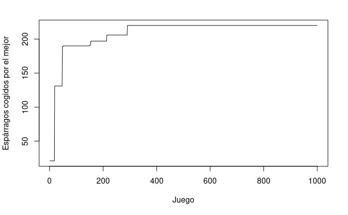

```r
# multiestado 4 contra la gorda
{

#---- Espacio y esparragueras iniciales
xmax <- 100  # ancho de la pradera (desde x = 1 hasta x = 100)
ymax <- 100  # largo "        "    (desde y = 1 hasta y = 100)
XYespar_ini <- t(as.matrix(read.table("XYesp_gorda.txt")))

#---- Veces
veces <- 1000
mejor <- numeric(veces)

#---- Tiempo
pasos <- 1200

#---- Movimiento
Dx <- c(0, 1, 0, -1)
Dy <- c(1, 0, -1, 0)
rota <- c(0, 270, 180, 90)

#---- Estados
estados <- "ABUN"

#---- Autómatas
automatas <- 12

#---- Cromosomas al azar
cromNa <- character()
for (i in 1:automatas){
  cromNa[i] <- ""
  for (j in 1:nchar(estados)) {
    for (k in 1:3){
      cromNa[i] <- paste(cromNa[i], sample(c(0,1), 1), sep = "") # lo que escribe
      cromNa[i] <- paste(cromNa[i], sample(c(1,2,3,4), 1), sep = "") # donde se mueve
      cromNa[i] <- paste(cromNa[i], sample(c(0,1,2,3), 1), sep = "") # nuevo estado
    }
  }
}

#---- Espárragos
Aea <- numeric(automatas)


for (vez in 1:veces){

    #---- JUGAR DE UNO EN UNO

    for (i in 1:automatas){

        #---- Pradera con esparragueras
        XYespar <- XYespar_ini

        #---- Posición y estado iniciales
        Ax <- ceiling(0.5*xmax)
        Ay <- ceiling(0.5*xmax)
        As <- 0  # estado A
        Ae <- 0  # sin espárragos

        #---- Paseo
        for (t in 2:pasos){

          # Mirar qué hay en la casilla
          huella  <- XYespar[Ax, Ay]

          # Coger espárrago (si lo hubiera)
          if (huella == 2) {Ae <- Ae + 1}

          # Aplicar la regla

          posi <- 9*As + 3*huella + 1  # para la nueva huella
          n_huella <- as.numeric(substring(cromNa[i], posi, posi))
          XYespar[Ax, Ay] <- n_huella

          posi <- 9*As + 3*huella + 2  # para el movimiento
          Ad <- as.numeric(substring(cromNa[i], posi, posi))

          posi <- 9*As + 3*huella + 3  # para el estado
          n_As <- as.numeric(substring(cromNa[i], posi, posi))
          As <- n_As

          # Moverse

          Ax <- Ax + Dx[Ad]
          Ay <- Ay + Dy[Ad]
          if(Ax > xmax) {Ax <- 1} # por si se sale
          if(Ax < 1) {Ax <- xmax}
          if(Ay > ymax) {Ay <- 1}
          if(Ay < 1) {Ay <- ymax}

        }

        #---- Asignar puntos
        Aea[i] <- Ae
    }

    #---- Ver quién gana y pierde
    e_ganador <- max(Aea)
    ganador <- min(which(Aea == e_ganador)) # para que solo salga uno
    e_pringao <- min(Aea)
    pringao <- min(which(Aea == e_pringao)) # para que solo salga uno
    mejor[vez] <- e_ganador

    # Pa grabá al ganador
    if (vez == veces) {
     print(paste(ganador, cromNa[ganador], e_ganador))
    }


    #---- Tranfulla 1 (copiar del ganador)
    amigo <- ganador  # para copiar el resto del cartón
    while (amigo == ganador){
      amigo <- floor(automatas*runif(1)) + 1
    }
    l_cromo <- nchar(cromNa[1])
    pc <- floor(l_cromo*runif(1)) + 1
    fc <- floor(l_cromo*runif(1)) + 1

    if (pc < fc) {
      cromNa[pringao] <- cromNa[amigo]
      substring(cromNa[pringao], pc, fc-1) <- substring(cromNa[ganador], pc, fc-1)
    }

    if (fc < pc) {
      cromNa[pringao] <- cromNa[ganador]
      substring(cromNa[pringao], fc, pc-1) <- substring(cromNa[amigo], fc, pc-1)
    }


    #---- Tranfulla 2 (cambiar algún número al tuntún)
    amigo <- floor(automatas*runif(1)) + 1
    pc <- floor(l_cromo*runif(1)) + 1
    pcc <- substring(cromNa[amigo], pc, pc)
    ifelse(pc%%3 == 0, # cambia el estado final
           substring(cromNa[amigo], pc, pc) <- as.character((as.numeric(pcc)+
                                                               floor(3*runif(1))+1
                                                               )%%4),
           ifelse(pc%%3 == 1, # cambia la nueva huella
                  substring(cromNa[amigo], pc, pc) <- as.character((as.numeric(pcc)+1)%%2),
                  substring(cromNa[amigo], pc, pc) <- as.character((as.numeric(pcc)+
                                                                    floor(3*runif(1))+1
                                                                      )%%4 + 1)
           ))
}
plot(mejor, type = "l", ylab = "Espárragos cogidos por el mejor", xlab = "Juego")
}
```

`MULTIESTADO (4)`

[video not shown]

## Evolución del direccional

¡A ver si la encuentra!

```
[1] "1 010012111311021200120312 297"
```

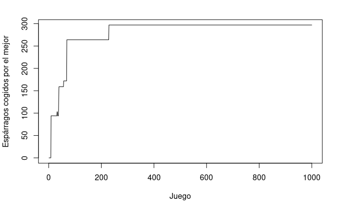

```r
# Autómata direccional contra la gorda
{

#---- Espacio y esparragueras iniciales
xmax <- 100  # ancho de la pradera (desde x = 1 hasta x = 100)
ymax <- 100  # largo "        "    (desde y = 1 hasta y = 100)
XYespar_ini <- t(as.matrix(read.table("XYesp_gorda.txt")))

#---- Veces
veces <- 1000
mejor <- numeric(veces)

#---- Tiempo
pasos <- 1200

#---- Movimiento
Dx <- c(0, 1, 0, -1)
Dy <- c(1, 0, -1, 0)
rota <- c(0, 270, 180, 90)

#---- Estados
estados <- "AAAA"

#---- Autómatas
automatas <- 12

#---- Cromosomas al azar
cromNa <- character()
for (i in 1:automatas){
  cromNa[i] <- ""
  for (j in 1:nchar(estados)) {
    for (k in 1:3){
      cromNa[i] <- paste(cromNa[i], sample(c(0,1), 1), sep = "") # lo que escribe
      cromNa[i] <- paste(cromNa[i], sample(c(0,1,2,3), 1), sep = "") # donde gira
    }
  }
}

#---- Espárragos
Aea <- numeric(automatas)


for (vez in 1:veces){

    #---- JUGAR DE UNO EN UNO

    for (i in 1:automatas){

        #---- Pradera con esparragueras
        XYespar <- XYespar_ini

        #---- Posición y estado iniciales
        Ax <- ceiling(0.5*xmax)
        Ay <- ceiling(0.5*ymax)
        As <- 0  # mirando al norte
        Ae <- 0  # sin espárragos

        #---- Paseo
        for (t in 2:pasos){

          # Mirar qué hay en la casilla
          huella  <- XYespar[Ax, Ay]

          # Coger espárrago (si lo hubiera)
          if (huella == 2) {Ae <- Ae + 1}

          # Aplicar la regla

          posi <- 6*As + 2*huella + 1  # para la nueva huella
          n_huella <- as.numeric(substring(cromNa[i], posi, posi))
          XYespar[Ax, Ay] <- n_huella

          posi <- 6*As + 2*huella + 2  # para el giro
          Ad <- as.numeric(substring(cromNa[i], posi, posi))

          As <- (As + Ad) %% 4

          # Moverse

          Ax <- Ax + Dx[As+1]
          Ay <- Ay + Dy[As+1]
          if(Ax > xmax) {Ax <- 1} # por si se sale
          if(Ax < 1) {Ax <- xmax}
          if(Ay > ymax) {Ay <- 1}
          if(Ay < 1) {Ay <- ymax}

        }

        #---- Asignar puntos
        Aea[i] <- Ae
    }

    #---- Ver quién gana y pierde
    e_ganador <- max(Aea)
    ganador <- min(which(Aea == e_ganador)) # para que solo salga uno
    e_pringao <- min(Aea)
    pringao <- min(which(Aea == e_pringao)) # para que solo salga uno
    mejor[vez] <- e_ganador

    # Pa grabá al ganador
    if (vez == veces) {
     print(paste(ganador, cromNa[ganador], e_ganador))
    }

    #---- Tranfulla 1 (copiar del ganador)
    amigo <- ganador  # para copiar el resto del cartón
    while (amigo == ganador){
      amigo <- floor(automatas*runif(1)) + 1
    }
    l_cromo <- nchar(cromNa[1])
    pc <- floor(l_cromo*runif(1)) + 1
    fc <- floor(l_cromo*runif(1)) + 1

    if (pc < fc) {
      cromNa[pringao] <- cromNa[amigo]
      substring(cromNa[pringao], pc, fc-1) <- substring(cromNa[ganador], pc, fc-1)
    }

    if (fc < pc) {
      cromNa[pringao] <- cromNa[ganador]
      substring(cromNa[pringao], fc, pc-1) <- substring(cromNa[amigo], fc, pc-1)
    }


    #---- Tranfulla 2 (cambiar algún número al tuntún)
    amigo <- floor(automatas*runif(1)) + 1
    pc <- floor(l_cromo*runif(1)) + 1
    pcc <- substring(cromNa[amigo], pc, pc)
    ifelse(pc%%2 == 0,
           # cambia el tipo de giro
           substring(cromNa[amigo], pc, pc) <- as.character((as.numeric(pcc)+
                                                               floor(3*runif(1))+1
                                                             )%%4),
           # cambia la nueva huella
           substring(cromNa[amigo], pc, pc) <- as.character((as.numeric(pcc)+1)%%2))

}
plot(mejor, type = "l", ylab = "Espárragos cogidos por el mejor", xlab = "Juego")
}
```

`DIRECCIONAL`

[video not shown]

La evolución parece más rápida????